# capC-MAP Downstream Analysis in R

Chris Brackley

26 November 2018

The main packages used are :

- ggplot2 : a system for declaratively creating graphics, based on The Grammar of Graphics. Details can be found at https://ggplot2.tidyverse.org/
- Gviz : a bioconductor package for plotting data and annotation information along genomic coordinates, available at http://bioconductor.org/packages/release/bioc/html/Gviz.html
- TxDb.Mmusculus.UCSC.mm9.knownGene and Mus.musculus : bioconductor packages for retrieving gene annotation data available at http://bioconductor.org/packages/TxDb.Mmusculus.UCSC.mm9.knownGene/ and http://bioconductor.org/packages/Mus.musculus/

In addition to this, we will also need the tidyr, gridExtra and data.table packages. To load these in R use the following commands:

```r
library(ggplot2)
library(tidyr)
library(gridExtra)
library(Gviz)
library(TxDb.Mmusculus.UCSC.mm9.knownGene)
library(Mus.musculus)
library(data.table)
```

### Plot per experiment statistics

capC-MAP generates a file ‘captured_report.dat’ which contains information about read mapping, valid interactions, discarded reads etc. To read this file in R the following commands can be used:

```r
report <- readLines("data1/captured_report.dat")

total <- strtoi(tail(strsplit(report[[8]],split = " ")[[1]],1))
dups <- strtoi(tail(strsplit(report[[12]],split = " ")[[1]],4)[[1]])

inter <- strtoi(tail(strsplit(report[[24]],split = " ")[[1]],4)[[1]])
intra <- strtoi(tail(strsplit(report[[25]],split = " ")[[1]],4)[[1]])

totalvalid <- inter + intra

exclusion <- strtoi(tail(strsplit(report[[20]],split = " ")[[1]],4)[[1]])
multitarget <- strtoi(tail(strsplit(report[[18]],split = " ")[[1]],4)[[1]])
nonmapped <- strtoi(tail(strsplit(report[[16]],split = " ")[[1]],4)[[1]])
noreporter <- strtoi(tail(strsplit(report[[19]],split = " ")[[1]],4)[[1]])
notarget <- strtoi(tail(strsplit(report[[17]],split = " ")[[1]],4)[[1]])
```

Plots showing the level of PCR duplicates, proportions of different types of discarded reads, and the total fraction of intra- and inter- chromosomal reads can be generated with:

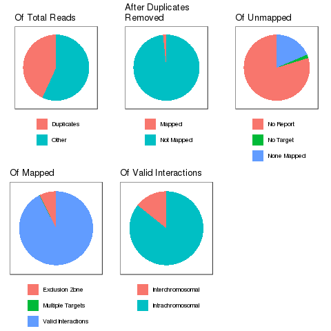

```r
strip <- theme(legend.position="none") + theme_bw() +
         theme(axis.text=element_blank(),axis.ticks=element_blank(),
               panel.grid=element_blank()) +
         theme(axis.title.x = element_blank(),axis.title.y = element_blank())

df <- data.frame(group=c("Duplicates","Other"),value = c(dups, total))
pie <- ggplot(df, aes(x="", y=value, fill=group)) + geom_bar(width = 1, stat = "identity") +
       coord_polar(theta="y")
p1 <- pie + strip + ggtitle(" \nOf Total Reads")+labs(fill="") +
            guides(fill=guide_legend(nrow=3,byrow=TRUE)) +
            theme(legend.position="bottom",legend.margin = unit(x=c(0,0,0,0),units="mm"))

df <- data.frame(group=c("Mapped","Not Mapped"),
               value = c(totalvalid+exclusion+multitarget, nonmapped+noreporter+notarget))
pie <- ggplot(df, aes(x="", y=value, fill=group)) +
       geom_bar(width = 1, stat = "identity")+coord_polar(theta="y")
p2 <- pie + strip + ggtitle("After Duplicates\nRemoved") + labs(fill="") +
            guides(fill=guide_legend(nrow=3,byrow=TRUE)) +
            theme(legend.position="bottom", legend.margin = unit(x=c(0,0,0,0),units="mm"))

df <- data.frame(group=c("None Mapped","No Report","No Target"),
                 value = c(nonmapped, notarget,noreporter))
pie <- ggplot(df, aes(x="", y=value, fill=group)) + geom_bar(width = 1, stat = "identity") +
       coord_polar(theta="y")
p3 <- pie + strip + ggtitle(" \nOf Unmapped") + labs(fill="") +
            guides(fill=guide_legend(nrow=3,byrow=TRUE)) +
            theme(legend.position="bottom",legend.margin = unit(x=c(0,0,0,0),units="mm"))

df <- data.frame(group=c("Valid Interactions","Multiple Targets","Exclusion Zone"),
                 value = c(totalvalid, multitarget,exclusion))
pie <- ggplot(df, aes(x="", y=value, fill=group)) + geom_bar(width = 1, stat = "identity") +
       coord_polar(theta="y")
p4 <- pie + strip + ggtitle("Of Mapped")+labs(fill="") +
            guides(fill=guide_legend(nrow=3,byrow=TRUE)) +
            theme(legend.position="bottom",legend.margin = unit(x=c(0,0,0,0),units="mm"))

df <- data.frame(group=c("Intrachromosomal","Interchromosomal"),value = c(intra, inter))
pie <- ggplot(df, aes(x="", y=value, fill=group)) + geom_bar(width = 1, stat = "identity") +
       coord_polar(theta="y")
p5 <- pie + strip + ggtitle("Of Valid Interactions")+labs(fill="") +
            guides(fill=guide_legend(nrow=3,byrow=TRUE)) +
            theme(legend.position="bottom",legend.margin = unit(x=c(0,0,0,0),units="mm"))

png("rplots/pie_charts.png")
grid.arrange(p1, p2, p3, p4, p5, nrow=2)
dev.off()
```

### Plot per target statistics

capC-MAP also outputs statistics on each target in the file ‘captured_interactioncounts.dat’, which can be read into R using the following commands:

```r
pt_stats <- read.table("data1/captured_interactioncounts.dat")
colnames(pt_stats)<-c("target_names","intra_rds","inter_rds","tot_rds","V5","V6")

target_names <- pt_stats$target_names

#calculate percentages and ratios
pt_stats["intra_rds_p"] <- 100*(pt_stats$intra_rds/pt_stats$tot_rds)
pt_stats["inter_rds_p"] <- 100*(pt_stats$inter_rds/pt_stats$tot_rds)
pt_stats["ratio"] <- pt_stats$inter_rds/pt_stats$intra_rds

#convert wide table to long table for stacked bar plot
pt_stats_short<-pt_stats[,1:3]
pt_stats_short <- pt_stats_short %>% gather(inter_rds, intra_rds, -c(target_names))
colnames(pt_stats_short)<-c("target_names","type","rds")
```

To generate bar plots showing interactions:

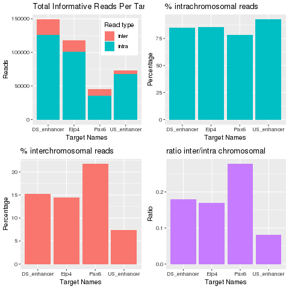

```r
p<-ggplot(data=pt_stats_short, aes(x=target_names, y=rds, fill=type)) + geom_col()
p1 <- p + ggtitle("Total Informative Reads Per Target") + xlab("Target Names") +
          ylab("Reads") +
          scale_fill_discrete(name="Read type", breaks=c("inter_rds", "intra_rds"),
                              labels=c("Inter","Intra"))+
          theme(legend.position = c(0.8, 0.2)) +
          theme(legend.position = c(0.8, 0.8))

p <- ggplot(data=pt_stats, aes(x=target_names, y=intra_rds_p)) +
     geom_bar(stat="identity",fill="#00BFC4")
p2 <- p + ggtitle("% intrachromosomal reads") + xlab("Target Names") + ylab("Percentage")

p <- ggplot(data=pt_stats, aes(x=target_names, y=inter_rds_p)) +
     geom_bar(stat="identity",fill="#F8766D")
p3 <- p + ggtitle("% interchromosomal reads") + xlab("Target Names") + ylab("Percentage")

p <- ggplot(data=pt_stats, aes(x=target_names, y=ratio)) +
     geom_bar(stat="identity",fill="#C77CFF")
p4 <- p + ggtitle("ratio inter/intra chromosomal") + xlab("Target Names") +ylab("Ratio")

png("rplots/bargraphs.png")
grid.arrange(p1, p2, p3, p4, nrow=2)
dev.off()
```

Similarly, plots showing the % of local (<1Mbp) interactions can be generated:

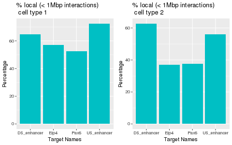

```r
pt_stats1 <- read.table("data1/captured_interactioncounts.dat")
pt_stats2 <- read.table("data2/captured_interactioncounts.dat")
colnames(pt_stats1)[1]<-"target_names"
colnames(pt_stats2)[1]<-"target_names"
pt_stats1["local_inter_cell_1"] <- 100*(pt_stats1$V6/pt_stats1$V4)
pt_stats2["local_inter_cell_2"] <- 100*(pt_stats2$V6/pt_stats2$V4)

p <- ggplot(data=pt_stats1, aes(x=target_names, y=local_inter_cell_1)) +
     geom_bar(stat="identity",fill="#00BFC4")
p1 <- p + ggtitle("% local (< 1Mbp interactions)\n cell type 1") + xlab("Target Names") +
          ylab("Percentage")
p <- ggplot(data=pt_stats2, aes(x=target_names, y=local_inter_cell_2)) +
     geom_bar(stat="identity",fill="#00BFC4")
p2 <- p + ggtitle("% local (< 1Mbp interactions)\n cell type 2") + xlab("Target Names") +
          ylab("Percentage")

png("rplots/local_long.png",height=300)
grid.arrange(p1, p2, ncol=2)
dev.off()
```

### Plot interaction profiles with different binning / smoothing parameters

The Gviz package from bioconductor can be used for plotting bed and bedGraph files alongside gene annotations.

First, set a data range to plot, and load these profiles:

```r
thechr <- "chr2"
st <- 105100000
en <- 105800000

txdb<-TxDb.Mmusculus.UCSC.mm9.knownGene

raw_bdg1 <- fread('data1/captured_normalizedpileup_Pax6.bdg',
                  col.names = c('chromosome', 'start', 'end', 'value'))
raw_bdg1_chr <- raw_bdg1[chromosome == thechr]

raw_bdg2 <- fread('data1/captured_bin_200_2000_RPM_Pax6.bdg',
                  col.names = c('chromosome', 'start', 'end', 'value'))
raw_bdg2_chr <- raw_bdg2[chromosome == thechr]

raw_bdg3 <- fread('data1/captured_bin_500_1000_RPM_Pax6.bdg',
                  col.names = c('chromosome', 'start', 'end', 'value'))
raw_bdg3_chr <- raw_bdg3[chromosome == thechr]

raw_bdg4 <- fread('data1/captured_bin_3000_6000_RPM_Pax6.bdg',
                  col.names = c('chromosome', 'start', 'end', 'value'))
raw_bdg4_chr <- raw_bdg4[chromosome == thechr]
```

To generate plots of the interaction profile from one of the targets at different binning and smoothing levels:

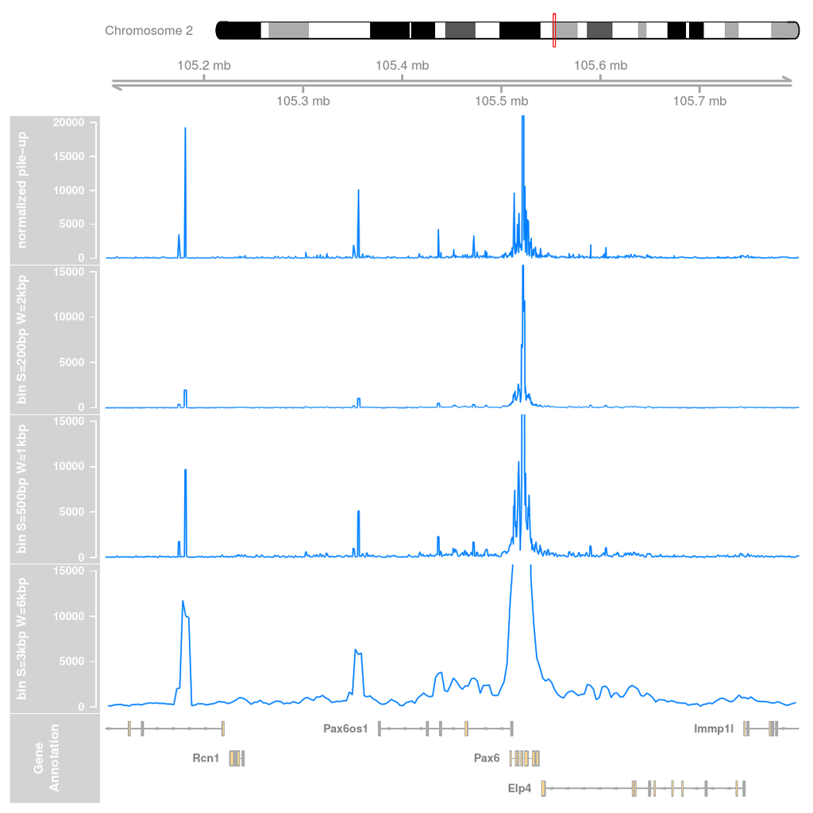

```r
dtrack1 <- DataTrack(range = raw_bdg1_chr, type = "a",genome = 'mm9',
                     name = "normalized pile-up", ylim = c(0,20000))
dtrack2 <- DataTrack(range = raw_bdg2_chr, type = "a",genome = 'mm9',
                     name = "bin S=200bp W=2kbp", ylim = c(0,15000))
dtrack3 <- DataTrack(range = raw_bdg3_chr, type = "a",genome = 'mm9',
                     name = "bin S=500bp W=1kbp", ylim = c(0,15000))
dtrack4 <- DataTrack(range = raw_bdg4_chr, type = "a",genome = 'mm9',
                     name = "bin S=3kbp W=6kbp", ylim = c(0,15000))
itrack <- IdeogramTrack(genome = "mm9", chromosome = thechr)
gtrack <- GenomeAxisTrack()

grtrack <- GeneRegionTrack(txdb,chromosome = thechr, start = st, end = en,
                          name = "Gene Annotation",collapseTranscripts = 'meta',
                          geneSymbols=TRUE,stackHeight=0.5,min.height=1)
# Add gene names instead of id numbers
symbols <- unlist(mapIds(org.Mm.eg.db, gene(grtrack),
                         "SYMBOL", "ENTREZID", multiVals = "first"))
symbol(grtrack) <- symbols[gene(grtrack)]

pdf("rplots/bin_interactions.pdf")
plotTracks(list(itrack, gtrack, dtrack1,dtrack2,dtrack3,dtrack4, grtrack),
          from = st, to = en)
dev.off()
```

### Plot interaction profiles from different targets

Instead plot the interaction profiles for several targets:

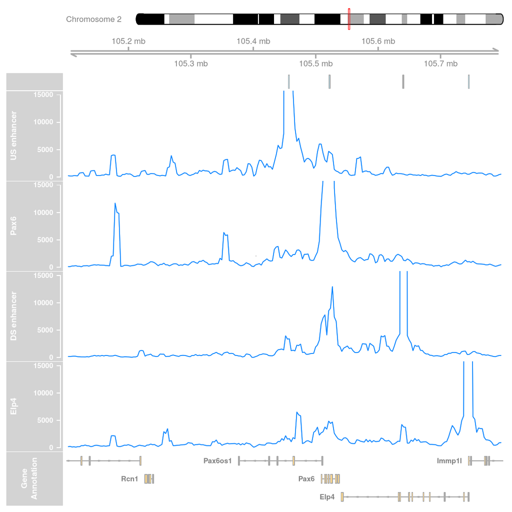

```r
thechr <- "chr2"
st <- 105100000
en <- 105800000

raw_bdg1 <- fread('data1/captured_bin_3000_6000_RPM_US_enhancer.bdg',
                  col.names = c('chromosome', 'start', 'end', 'value'))
raw_bdg1_chr <- raw_bdg1[chromosome == thechr]

raw_bdg2 <- fread('data1/captured_bin_3000_6000_RPM_Pax6.bdg',
                  col.names = c('chromosome', 'start', 'end', 'value'))
raw_bdg2_chr <- raw_bdg2[chromosome == thechr]

raw_bdg3 <- fread('data1/captured_bin_3000_6000_RPM_DS_enhancer.bdg',
                  col.names = c('chromosome', 'start', 'end', 'value'))
raw_bdg3_chr <- raw_bdg3[chromosome == thechr]

raw_bdg4 <- fread('data1/captured_bin_3000_6000_RPM_Elp4.bdg',
                  col.names = c('chromosome', 'start', 'end', 'value'))
raw_bdg4_chr <- raw_bdg4[chromosome == thechr]


dtrack1 <- DataTrack(range = raw_bdg1_chr, type = "a",genome = 'mm9',name = "US enhancer",
                     ylim = c(0,15000))
dtrack2 <- DataTrack(range = raw_bdg2_chr, type = "a",genome = 'mm9',name = "Pax6",
                     ylim = c(0,15000))
dtrack3 <- DataTrack(range = raw_bdg3_chr, type = "a",genome = 'mm9',name = "DS enhancer",
                     ylim = c(0,15000))
dtrack4 <- DataTrack(range = raw_bdg4_chr, type = "a",genome = 'mm9',name = "Elp4",
                     ylim = c(0,15000))
itrack <- IdeogramTrack(genome = "mm9", chromosome = thechr)
gtrack <- GenomeAxisTrack()

targets <- fread('data1/targets.bed',col.names=c('chromosome','start','end','V4','name'))
ttrack <- AnnotationTrack(targets,shape='box',chromosome=thechr,name="targets",
                          stack.height=0.25)

pdf("rplots/target_interactions.pdf")
plotTracks(list(itrack, gtrack,ttrack, dtrack1,dtrack2,dtrack3,dtrack4, grtrack),
           from = st, to = en)
dev.off()
```